# TRUST4 SHM analysis - WT vs KO project

## Overview and setup

### Analysis overview

**Author(s):** Gisela Gabernet  
**Last Updated:** 2024-07-08

**R version:** R version 4.3.2 (2023-10-31)  
**Platform:** x86_64-pc-linux-gnu  
**Running under:** Ubuntu 22.04.3 LTS

### Script setup

If you are running this Rmd file within RStudio, make sure that “Knit Directory” is set to “Current Working Directory”.

```r
# make sure the environment is clear of user objects
# note that custom set working directories, loaded libraries, etc. will be unaffected
# you may need to fully restart R for reproducibility
#rm(list = ls())

# define the working directory
path_base <- file.path("") # operating system (Linux, Windows, Mac)
# setwd(path_base) # not recommended

# set the data directory
path_data_root <- file.path("/mnt/volume/Projects/lucas_trust4/results_WT_KO") # operating system (Linux, Windows, Mac)


# set options if desired
options(encoding = "UTF-8") # instead of ANSI

# Need to install from source due to incompatibilities
#remove.packages("Matrix")
#remove.packages("irlba")
#install.packages("Matrix",type="source", dependencies=T)
#install.packages("irlba",type="source", dependencies=T)

# list (and install if needed) CRAN packages
packages <- c("alakazam", "kableExtra", "knitr", "patchwork", "dplyr", "ggplot2",
              "RColorBrewer", "rlang", "Seurat", "stringr", "tidyverse",
              "Matrix", "irlba", "clustree", "ggpubr") # some people prefer cowplot over patchwork
new_pkg <- packages[!(packages %in% installed.packages())]
if (length(new_pkg)) {install.packages(new_pkg)}

# list (and install if needed) Bioconductor packages
packages_additional <- c()
new_pkg_additional <- packages_additional[!(packages_additional %in% installed.packages())]
if (length(new_pkg_additional)) {BiocManager::install(new_pkg_additional)}

# load packages
packages <- sort(append(packages, packages_additional)) # so the list of versions will be in order
for (n in seq_along(packages)) {
  suppressPackageStartupMessages(library(packages[n], character.only = TRUE))
  cat(paste0(packages[n], ": ", packageVersion(packages[n]), "\n")) # print simplified package versions
}
```

```
alakazam: 1.3.0
clustree: 0.5.1
dplyr: 1.1.3
ggplot2: 3.4.4
ggpubr: 0.6.0
irlba: 2.3.5.1
kableExtra: 1.3.4
knitr: 1.45
Matrix: 1.6.5
patchwork: 1.1.3
RColorBrewer: 1.1.3
rlang: 1.1.2
Seurat: 4.4.0
stringr: 1.5.1
tidyverse: 2.0.0
```

```r
# remove unnecessary variables
rm(n, new_pkg, new_pkg_additional, packages, packages_additional)
```

### Visualization and themes

This will help the figures created later on to be more standardized and interpretable:

```r
theme_set(theme_classic())

# to help distinguish between different groups during visualization (violin plots, UMAPs, etc.)
#source(here::here("scripts", "colors.R"))
```

```r
# or whatever sizes and themes you want
#source(here::here("scripts", "themes.R"))
```

## Results with alignment high quality filter

Results with BCR sequences with >200 aligned positions and max 10% N nucleotides.

### Reading data

```r
rep_dir <- file.path(path_data_root,"clonal_analysis","define_clones","all_reps_clone_report","repertoires")
rep_files_list <- list.files(rep_dir)

rep_list_path <- lapply(rep_files_list, function(x) file.path(rep_dir,x))

rep_list <- lapply(rep_list_path, airr::read_rearrangement)
bcr_data <- dplyr::bind_rows(rep_list)

print("Loaded BCR data from samples:")
```

```
[1] "Loaded BCR data from samples:"
```

```r
unique(bcr_data$sample_id)
```

```
[1] "KO1" "KO3" "KO4" "KO5" "WT1" "WT2" "WT4" "WT5"
```

```r
rm(rep_files_list, rep_list_path, rep_list)

#Make mu_freq_numeric, filter consensus count > 1
bcr_data_filt <- bcr_data %>%
             dplyr::filter(consensus_count > 1) %>%
             dplyr::filter(locus == "IGH") %>%
             dplyr::mutate(mu_freq = as.numeric(mu_freq),
                           group = ifelse(grepl("WT",sample_id),"WT","KO"),
                           isotype_coarse = str_sub(isotype,1,4))
```

### Number of sequences per sample

Heavy chains only

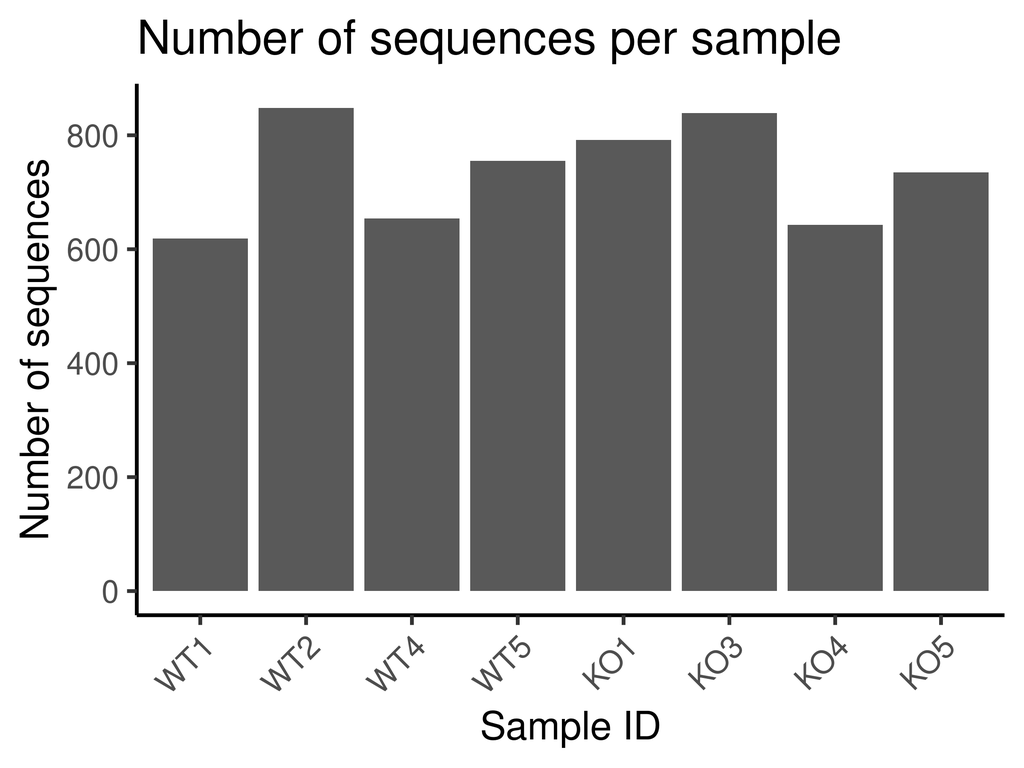

```r
bcr_data_filt$sample_id <- factor(bcr_data_filt$sample_id,
                                     levels=c("WT1","WT2","WT4","WT5",
                                              "KO1","KO3","KO4","KO5"))
bcr_data_filt$group <- factor(bcr_data_filt$group, levels=c("WT","KO"))
n_seqs <- bcr_data_filt %>%
  dplyr::group_by(sample_id) %>%
  dplyr::summarize(n_seq = n())

ggplot(n_seqs, aes(x = sample_id, y = n_seq)) +
  geom_bar(stat = "identity") +
  theme(axis.text.x = element_text(angle = 45, hjust = 1)) +
  labs(title = "Number of sequences per sample", x = "Sample ID", y = "Number of sequences")
```

### SHM frequency plot

Heavy chains only

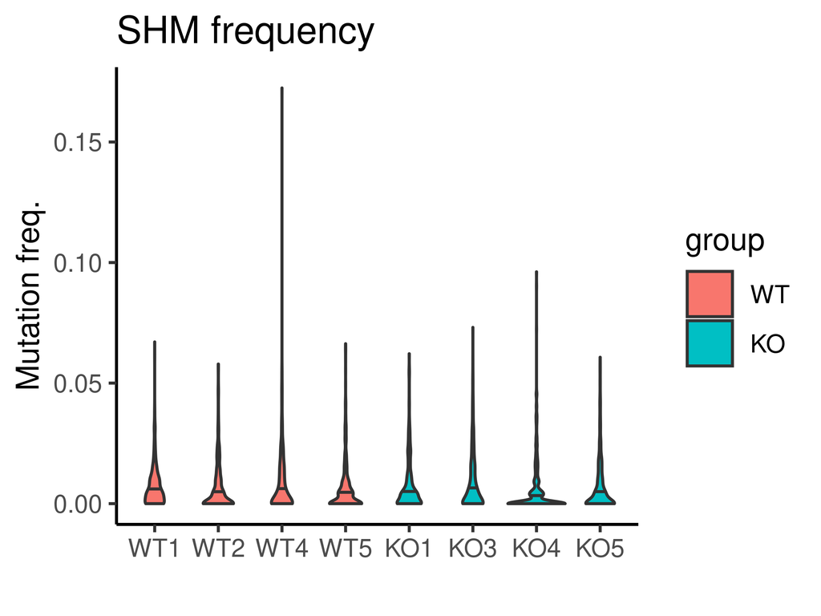

```r
ggplot(bcr_data_filt, aes(x= sample_id, y = mu_freq, fill=group)) +
  geom_violin(draw_quantiles = c(0.5)) +
  labs(title = "SHM frequency", x = "", y = "Mut. frequency") +
  labs(x="", y="Mutation freq.", title="SHM frequency")
```

### Compare mean SHM frequency

```r
mean_mu_freq <- bcr_data_filt %>%
  dplyr::group_by(sample_id,group) %>%
  dplyr::summarize(mean_mu_freq = mean(mu_freq), sd_mu_freq = sd(mu_freq))
```

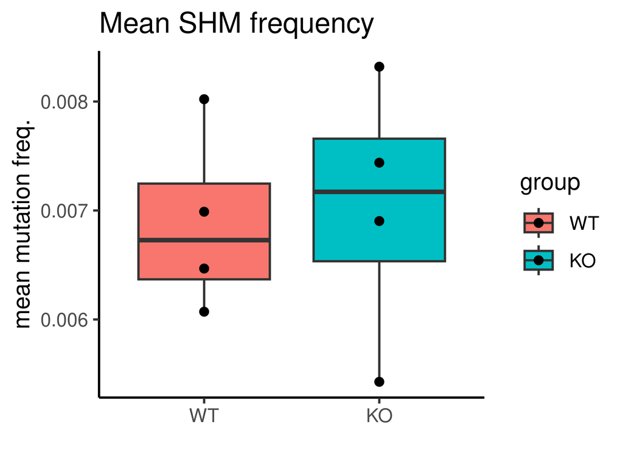

```r
ggplot(mean_mu_freq, aes(x = group, y = mean_mu_freq, fill = group)) +
  geom_boxplot() +
  geom_point() +
  labs(x = "", y = "mean mutation freq.", title = "Mean SHM frequency")
```

### Check percent isotype

```r
isotype_freq <- bcr_data_filt %>%
  dplyr::group_by(sample_id, group, isotype_coarse) %>%
  dplyr::summarize(n_seq = n()) %>%
  dplyr::mutate(perc_isotype = n_seq/sum(n_seq)*100)
```

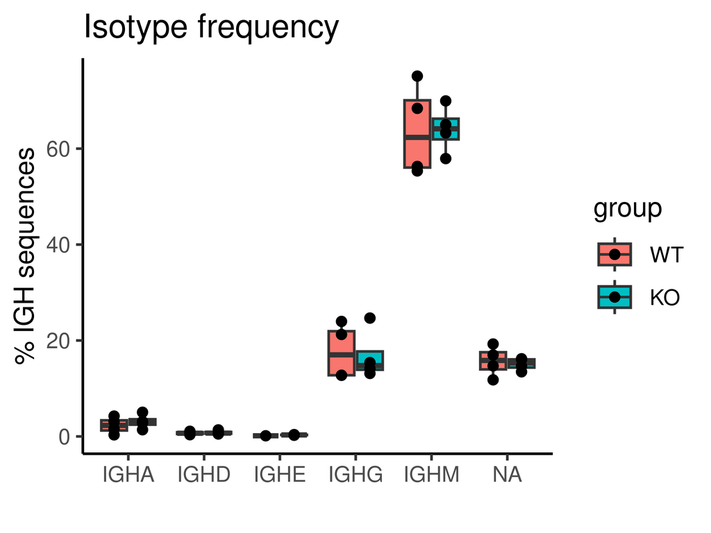

```r
ggplot(isotype_freq, aes(x = isotype_coarse, y = perc_isotype, fill = group)) +
  geom_boxplot() +
  geom_point(position = position_dodge(0.75)) +
  labs(title = "Isotype frequency", x = "", y = "% IGH sequences")
```

### Compare mean SHM frequency per isotype

```r
mean_mu_freq_isotype <- bcr_data_filt %>%
  dplyr::group_by(sample_id,group,isotype_coarse) %>%
  dplyr::summarize(mean_mu_freq = mean(mu_freq), sd_mu_freq = sd(mu_freq))
```

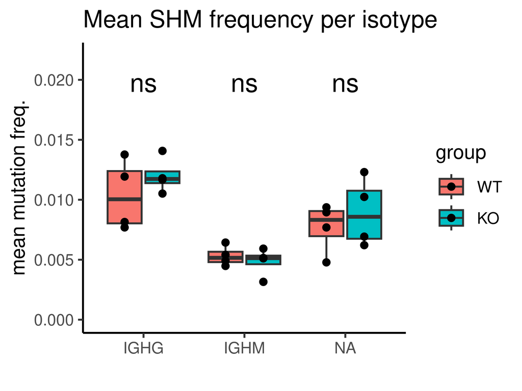

```r
ggplot(mean_mu_freq_isotype %>% filter(isotype_coarse %in% c("IGHG", "IGHM", NA)), aes(x = isotype_coarse, y = mean_mu_freq, fill = group)) +
  geom_boxplot() +
  geom_point(position = position_dodge(width = 0.75)) +
  stat_compare_means(method = "wilcox.test", label = "p.signif", size=5, label.y = 0.019) +
  scale_y_continuous(limits = c(0, 0.022)) +
labs(x="", y="mean mutation freq.", title="Mean SHM frequency per isotype")
```

### IGHV gene usage

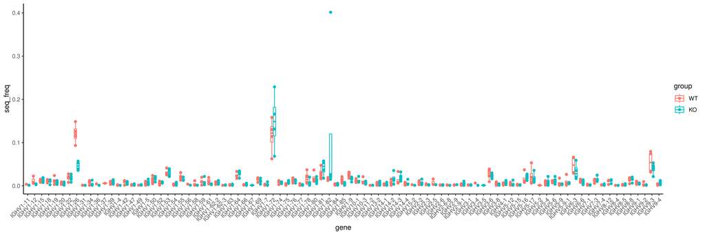

```r
vh_gene <- countGenes(bcr_data_filt, gene= "v_call", groups = "sample_id", mode="gene")

bcr_data_filt_meta <- bcr_data_filt %>%
  dplyr::select(sample_id, subject_id, group) %>%
  dplyr::distinct()

vh_gene_meta <- vh_gene %>%
  left_join(bcr_data_filt_meta, by = "sample_id")

ggplot(vh_gene_meta, aes(x = gene, y = seq_freq, color = group)) +
  geom_boxplot() +
  geom_point(position = position_dodge(width = 0.75)) +
  theme(axis.text.x = element_text(angle = 45, hjust = 1))
```

### IGHV1-72 usage (NP-OVA specific response)

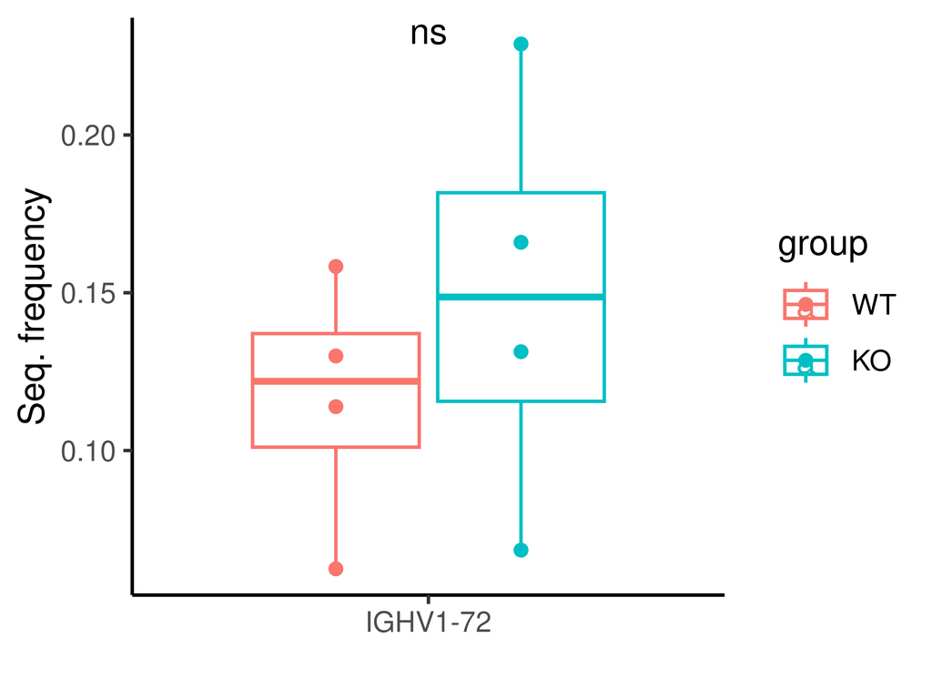

```r
vh172_freq <- vh_gene_meta %>%
  dplyr::filter(gene == "IGHV1-72")

ggplot(vh172_freq, aes(x = gene, y = seq_freq, color = group)) +
  geom_boxplot() +
  geom_point(position = position_dodge(width = 0.75)) +
  stat_compare_means(method = "wilcox.test", label = "p.signif") +
  labs(x="", y="Seq. frequency")
```

Number of IGHV1-72 sequences

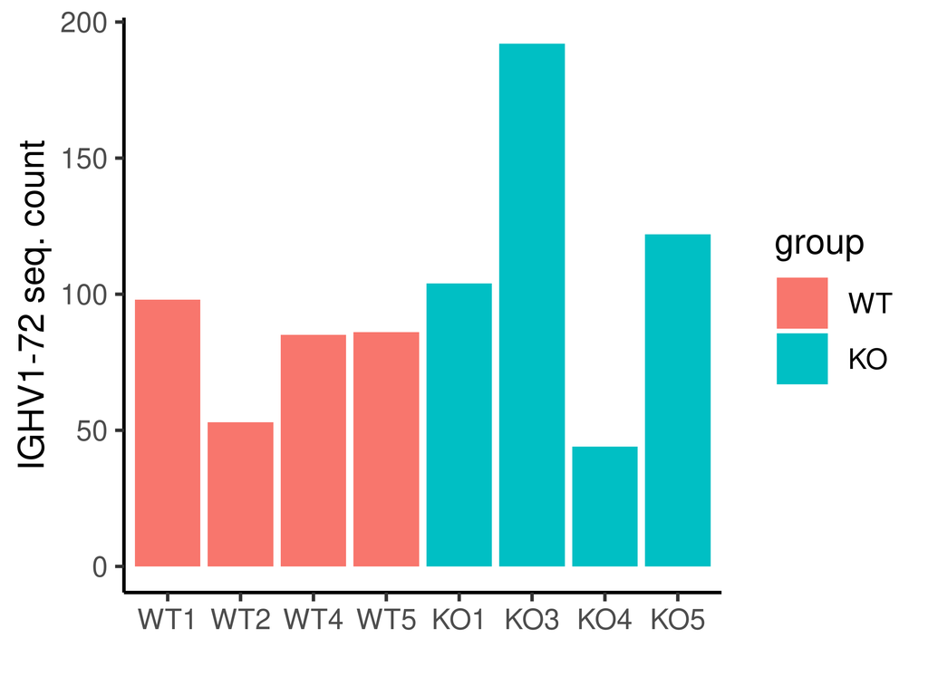

```r
ggplot(vh172_freq, aes(x=sample_id, y=seq_count, fill=group)) +
  geom_bar(stat="identity") +
  labs(x="", y="IGHV1-72 seq. count")
```

### Mutation frequency in IGHV1-72

```r
bcr_data_filt_IGHV172 <- bcr_data_filt %>%
  mutate(v_gene = alakazam::getGene(v_call)) %>%
  dplyr::filter(v_gene == "IGHV1-72")

mean_mu_freq_isotype <- bcr_data_filt_IGHV172 %>%
  dplyr::group_by(sample_id,group,isotype_coarse) %>%
  dplyr::summarize(mean_mu_freq = mean(mu_freq), sd_mu_freq = sd(mu_freq))
```

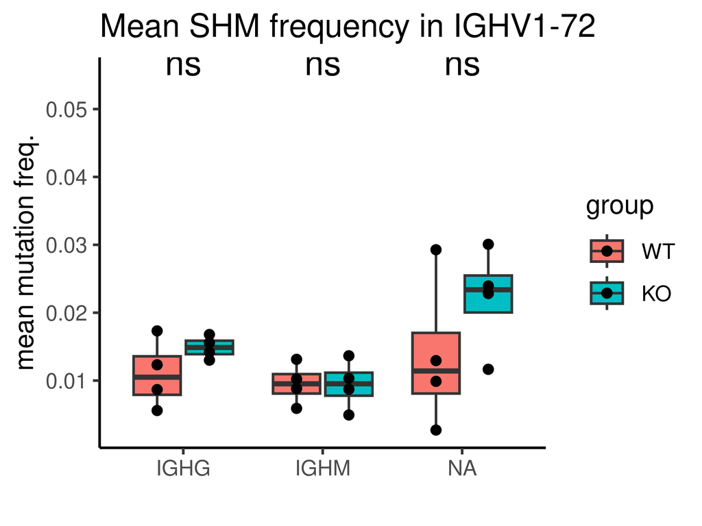

```r
ggplot(mean_mu_freq_isotype %>% filter(isotype_coarse %in% c("IGHG", "IGHM", NA)), aes(x = isotype_coarse, y = mean_mu_freq, fill = group)) +
  geom_boxplot() +
  geom_point(position = position_dodge(width = 0.75)) +
  stat_compare_means(method = "wilcox.test", label = "p.signif", size=5, label.y = 0.055) +
  #scale_y_continuous(limits = c(0, 0.06)) +
labs(x="", y="mean mutation freq.", title="Mean SHM frequency in IGHV1-72")
```

### Checking Trp (W) to Leu (L) conversions

Codon 33 in V186.2 for Rajewshy et al. 1987, Science As shown in [IMGT](http://www.imgt.org/IMGTrepertoire/index.php?section=LocusGenes&repertoire=genetable&species=Mus_musculus&group=IGHV). This corresponds to IMGT V1-72*01 Checking the translation shows a W at position 38 that matches the position and AA motif surrounding codon 33 of Rajewshy et al. 1987; namely, GYTFXXXXTSYWMHWVK in IMGT maps to GYTFSWMHVK in Fig 3.

IMGT `112:114` is codon number 38:

```r
shazam:::getCodonNumb(112:114)
```

```
[1] 38 38 38
```

Get subset of sequences with IGHV1-72 v_call, then translate the sequence alignment to amino acids to check for the W38L conversion.

```r
bcr_data_filt_IGHV172 <- bcr_data_filt_IGHV172 %>%
                    mutate( sequence_alignment_aa = translateDNA(sequence_alignment),
                            ighv172_codon38_nt = substr(sequence_alignment, start=112, stop=114),
                            ighv172_codon38_aa = alakazam:::translateDNA(ighv172_codon38_nt, trim=F)
                    ) %>%
                    mutate(across(c(sample_id, group, ighv172_codon38_aa), factor))
```

Number of sequences with W, L and X (unknown) at codon 38:

```r
count_codon <- bcr_data_filt_IGHV172 %>%
  group_by(sample_id, group) %>%
  summarize(count_W = sum(ighv172_codon38_aa == "W"),
            count_L = sum(ighv172_codon38_aa == "L"),
            count_X = sum(ighv172_codon38_aa == "X"),
            count_other = sum(!ighv172_codon38_aa %in% c("W", "L" ,"X")))
kable(count_codon)
```

| sample_id | group | count_W | count_L | count_X | count_other |
| --- | --- | --- | --- | --- | --- |
| WT1 | WT | 9 | 38 | 49 | 2 |
| WT2 | WT | 11 | 13 | 29 | 0 |
| WT4 | WT | 25 | 10 | 46 | 4 |
| WT5 | WT | 33 | 9 | 44 | 0 |
| KO1 | KO | 15 | 32 | 52 | 5 |
| KO3 | KO | 24 | 67 | 101 | 0 |
| KO4 | KO | 15 | 5 | 24 | 0 |
| KO5 | KO | 52 | 6 | 64 | 0 |

Percentages of W, L and X (unknown) at codon 38:

```r
perc_codon <- bcr_data_filt_IGHV172 %>%
  group_by(sample_id, group) %>%
  summarize(perc_W = sum(ighv172_codon38_aa == "W")/n() * 100,
            perc_L = sum(ighv172_codon38_aa == "L")/n() * 100,
            perc_X = sum(ighv172_codon38_aa == "X")/n() * 100,
            perc_other = sum(!ighv172_codon38_aa %in% c("W", "L" ,"X"))/n() * 100)
kable(perc_codon)
```

| sample_id | group | perc_W | perc_L | perc_X | perc_other |
| --- | --- | --- | --- | --- | --- |
| WT1 | WT | 9.183673 | 38.775510 | 50.00000 | 2.040816 |
| WT2 | WT | 20.754717 | 24.528302 | 54.71698 | 0.000000 |
| WT4 | WT | 29.411765 | 11.764706 | 54.11765 | 4.705882 |
| WT5 | WT | 38.372093 | 10.465116 | 51.16279 | 0.000000 |
| KO1 | KO | 14.423077 | 30.769231 | 50.00000 | 4.807692 |
| KO3 | KO | 12.500000 | 34.895833 | 52.60417 | 0.000000 |
| KO4 | KO | 34.090909 | 11.363636 | 54.54545 | 0.000000 |
| KO5 | KO | 42.622951 | 4.918033 | 52.45902 | 0.000000 |

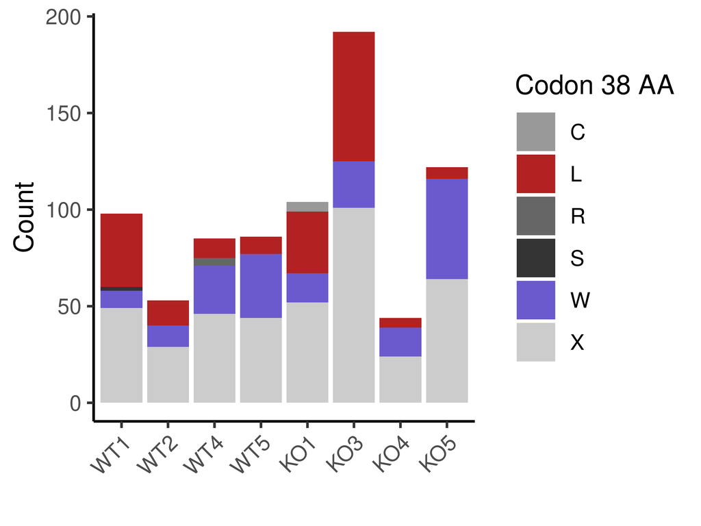

```r
ggplot(bcr_data_filt_IGHV172, aes(x=sample_id, fill=ighv172_codon38_aa)) +
  geom_bar() +
  scale_fill_manual(values = c("W" = "slateblue", "L" = "firebrick", "X" = "gray80", "C" = "gray60", "R" = "gray40", "S" = "gray20")) +
  theme(axis.text.x = element_text(angle = 45, hjust = 1)) +
  labs(x="", y="Count", fill="Codon 38 AA")
```

Barplot with percentages:

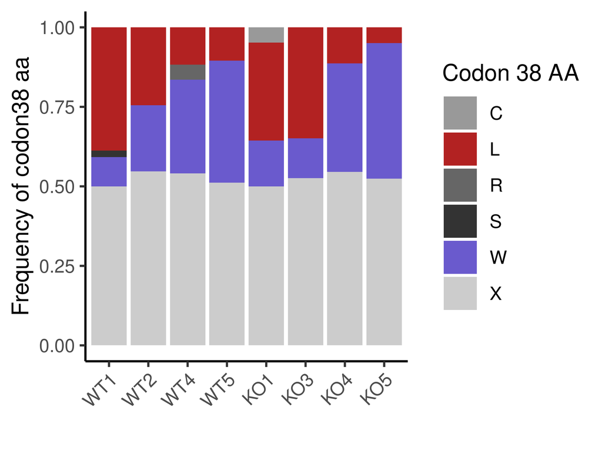

```r
bcr_data_filt_IGHV172 %>%
  ggplot(aes(x=sample_id, fill=ighv172_codon38_aa)) +
  geom_bar(position="fill") +
  scale_fill_manual(values = c("W" = "slateblue", "L" = "firebrick", "X" = "gray80", "C" = "gray60", "R" = "gray40", "S" = "gray20")) +
  theme(axis.text.x = element_text(angle = 45, hjust = 1)) +
  labs(x="", y="Frequency of codon38 aa", fill="Codon 38 AA")
```

### Compare %W38L across all mice

Calculate percentage of W38L from all IGHV1-72 sequences with known aa at codon 38:

```r
perc_W_L_ofknown <- bcr_data_filt_IGHV172 %>%
  dplyr::filter(!ighv172_codon38_aa %in% c("X")) %>%
  dplyr::group_by(sample_id, group) %>%
  dplyr::summarize(perc_W = sum(ighv172_codon38_aa == "W")/n() * 100,
            perc_L = sum(ighv172_codon38_aa == "L")/n() * 100)
```

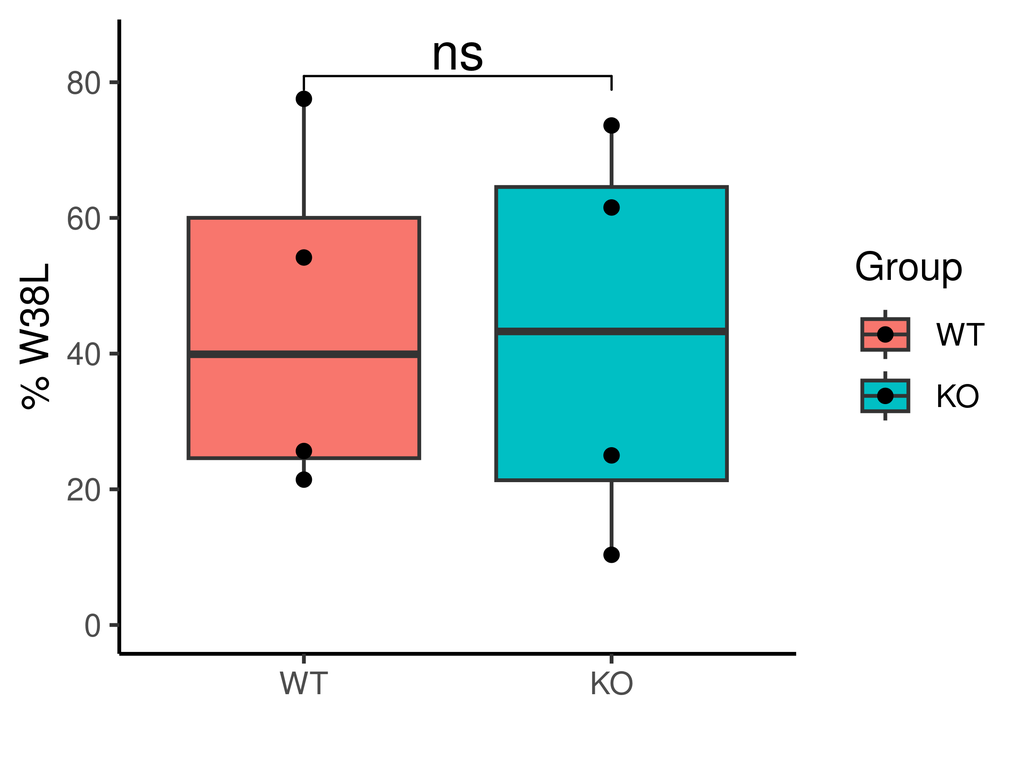

```r
ggplot(perc_W_L_ofknown, aes(x=group, y=perc_L, fill=group)) +
  geom_boxplot() +
  geom_point(position = position_dodge(width = 0.75)) +
  scale_y_continuous(limits = c(0, 85)) +
  stat_compare_means(comparisons = list(c("WT","KO")), method = "wilcox.test", label = "p.signif", size=5) +
  labs(x="", y="% W38L", fill="Group")
```